# R Bootcamp, Module 8: Graphics

Created by: Kellie Ottoboni and Chris Krogslund (UC Berkeley)  
Edited by: John Erickson (RPI IDEA)

January 2018 (RPI)

# By way of introduction...

- Three main facilities for producing graphics in R:
  - **base**
  - **lattice**
  - **ggplot2**
- In practice, these facilities are grouped into two camps: "basic" and "advanced"
- A better formulation:
  - **quick & dirty**
  - **involved, subtle, fancy, expressive...**

# The data

- All Summer Olympic medalists from 1896-2008
- Variables include: name, gender, country, country code (`NOC`), sporting event, and type of medal won
- We don't actually care about names of winners: we're interested in how many medals that different countries won

For more info, see [The Guardian Datablog Olympic medal winners: every one since 1896 as open data](https://www.theguardian.com/sport/datablog/2012/jun/25/olympic-medal-winner-list-data)

First, we'll use `dplyr` and `tidyr` to count the medals of each type won, for each country and each year.

```r
head(medals)
```

```
##     City    Sport Discipline               Athlete NOC Gender
## 1 Athens Aquatics   Swimming         HAJOS, Alfred HUN    Men
## 2 Athens Aquatics   Swimming      HERSCHMANN, Otto AUT    Men
## 3 Athens Aquatics   Swimming     DRIVAS, Dimitrios GRE    Men
## 4 Athens Aquatics   Swimming    MALOKINIS, Ioannis GRE    Men
## 5 Athens Aquatics   Swimming    CHASAPIS, Spiridon GRE    Men
## 6 Athens Aquatics   Swimming CHOROPHAS, Efstathios GRE    Men
##                        Event Event_gender  Medal Year Country
## 1             100m freestyle            M   Gold 1896 Hungary
## 2             100m freestyle            M Silver 1896 Austria
## 3 100m freestyle for sailors            M Bronze 1896  Greece
## 4 100m freestyle for sailors            M   Gold 1896  Greece
## 5 100m freestyle for sailors            M Silver 1896  Greece
## 6            1200m freestyle            M Bronze 1896  Greece
```

```r
# dplyr and tidyr refresher
medal_counts <- medals %>%
  group_by(Medal, Year, NOC) %>%
  summarise(count = n())
head(medal_counts)
```

```
## # A tibble: 6 x 4
## # Groups:   Medal, Year [1]
##    Medal  Year   NOC count
##    <chr> <int> <chr> <int>
## 1 Bronze  1896   AUT     2
## 2 Bronze  1896   DEN     3
## 3 Bronze  1896   FRA     2
## 4 Bronze  1896   GBR     2
## 5 Bronze  1896   GER     2
## 6 Bronze  1896   GRE    22
```

This table is in tidy format. Wide (untidy) format can be useful for plotting in base plot (more on this later)

```r
medal_counts_wide <- medal_counts %>% spread(key = Medal, value = count) %>%
  ungroup() %>%
  mutate(Bronze = ifelse(is.na(Bronze), 0, Bronze)) %>%
  mutate(Silver = ifelse(is.na(Silver), 0, Silver)) %>%
  mutate(Gold = ifelse(is.na(Gold), 0, Gold))
head(medal_counts_wide)
```

```
## # A tibble: 6 x 5
##    Year   NOC Bronze  Gold Silver
##   <int> <chr>  <dbl> <dbl>  <dbl>
## 1  1896   AUS      0     2      0
## 2  1896   AUT      2     2      1
## 3  1896   DEN      3     1      2
## 4  1896   FRA      2     5      4
## 5  1896   GBR      2     2      3
## 6  1896   GER      2    26      5
```

Finally, let's subset the data to gold medal counts for the US, for easier plotting.

```r
usa_gold_medals <-  medal_counts %>%
  filter(Medal == "Gold") %>%
  filter(NOC == "USA")
```

# Base graphics

The general call for base plot looks something like this:

```r
plot(x = , y = , ...)
```

Additional parameters can be passed in to customize the plot:

- type: scatterplot? lines? etc
- main: a title
- xlab, ylab: x-axis and y-axis labels
- col: color, either a string with the color name or a vector of color names for each point

More layers can be added to the plot with additional calls to `lines`, `points`, `text`, etc.

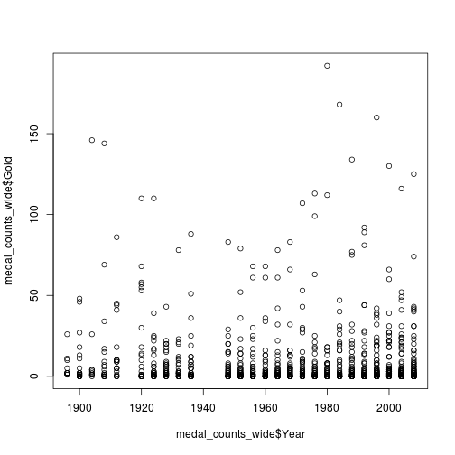

```r
plot(medal_counts_wide$Year, medal_counts_wide$Gold) # Basic
```

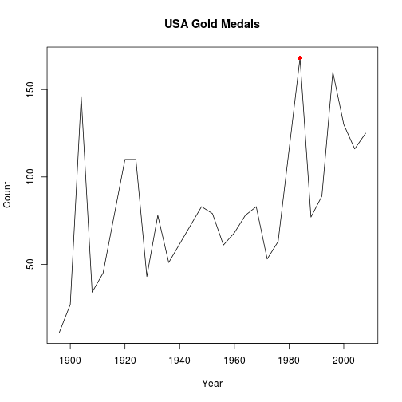

```r
plot(usa_gold_medals$Year, usa_gold_medals$count, type = "l",
     main = "USA Gold Medals",
     xlab = "Year", ylab = "Count") # with updated parameters
points(x = 1984, y = usa_gold_medals$count[usa_gold_medals$Year == 1984],
       col = "red", pch = 16)
```

## Other plot types

These are just a few other types of plots you can make in base graphics.

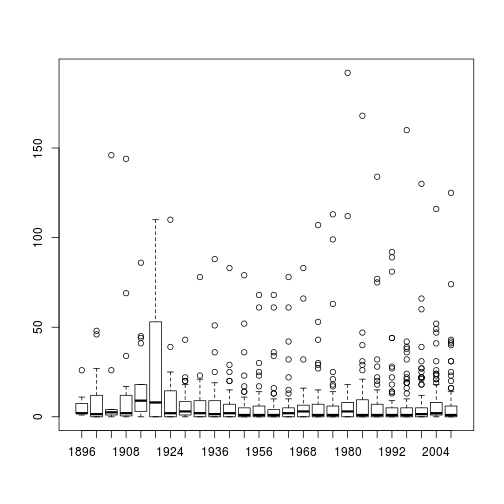

```r
boxplot(Gold~Year, data = medal_counts_wide)
```

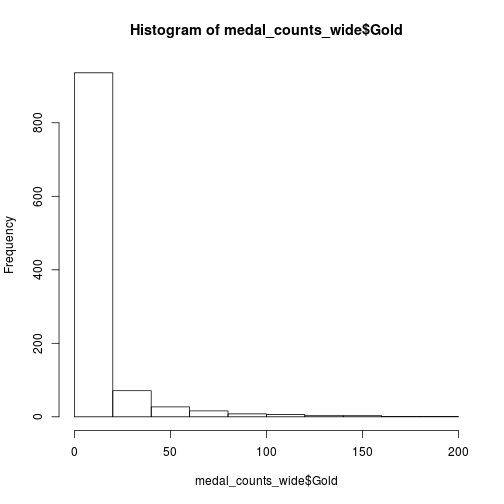

```r
hist(medal_counts_wide$Gold)
```

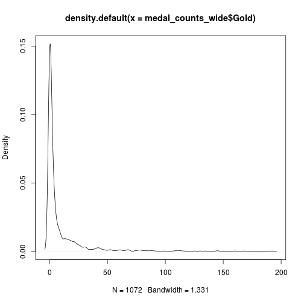

```r
plot(density(medal_counts_wide$Gold))
```

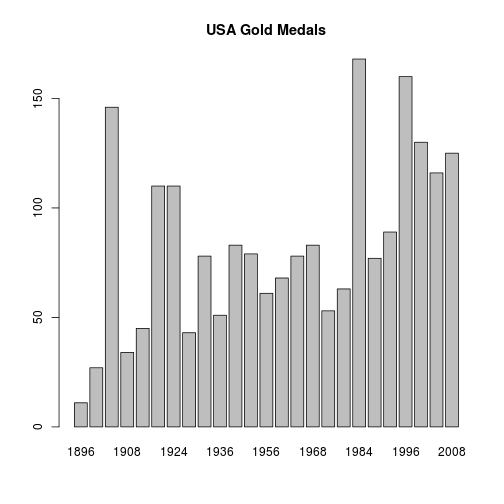

```r
barplot(usa_gold_medals$count, width = 4, names.arg = usa_gold_medals$Year,
                               main = "USA Gold Medals")
```

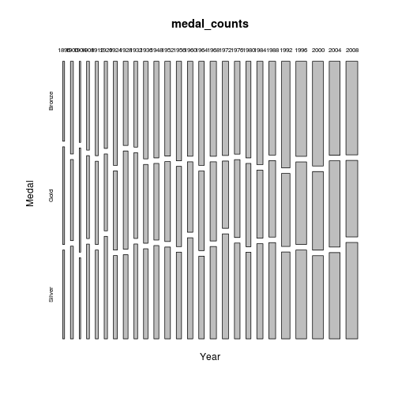

```r
mosaicplot(Year~Medal, medal_counts)
```

## Object-oriented plots

- Base graphics often recognizes the object type and will implement specific plot methods
- lattice and ggplot2 generally **don't** exhibit this sort of behavior

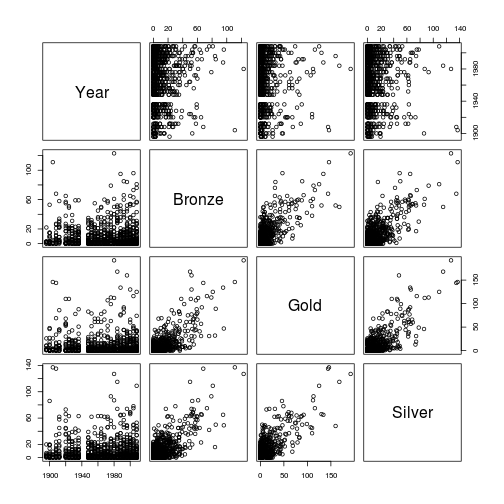

```r
medal_lm <- lm(Gold ~ Bronze + Silver, data = medal_counts_wide)
plot(medal_counts_wide %>% select(-NOC)) # Calls plotting method for class of the dataset ("data.frame")
```

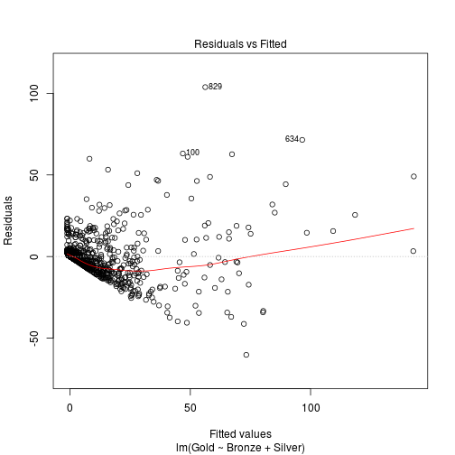

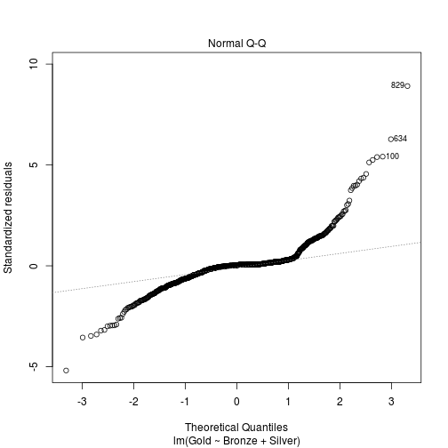

```r
plot(medal_lm, which=1:2) # Calls plotting method for class of medal_lm object ("lm"), print first two plots only
```

For a nice explanation (using R!) of regression diagnostics see e.g. [Regression diagnostic plots (CMU)](https://www.andrew.cmu.edu/user/achoulde/94842/homework/regression_diagnostics.html)

## Pros/cons of base graphics

- Good for exploratory data analysis and sanity checks
- Syntax is inconsistent across functions: some take x,y while others take formulas
- Defaults plotting parameters are ugly and it can be difficult to customize

# lattice and ggplot2

lattice is

1. faster (though only noticeable over many and large plots)
2. simpler (at first)
3. better at trellis graphs
4. able to do 3d graphs

ggplot2 is

1. generally more elegant
2. more syntactically logical (and therefore simpler, once you learn it)
3. better at grouping
4. able to interface with maps

# Basic usage: lattice

The general call for lattice graphics looks something like this:

```r
graph_type(formula, data = , [options])
```

The most common graph types:

- xyplot: generic scatterplot
- barchart
- bwplot: boxplot
- histogram
- cloud: 3D scatterplot

The specifics of the **formula** differ for each graph type, but the general format is straightforward

```r
~y             # Show the distribution of y

y~x           # Show the relationship between x and y

y~x|A         # Show the relationship between x and y conditional on the values of A

y~x|A*B       # Show the relationship between x and y conditional on the combinations of A and B

z~y*x         # Show the 3D relationship between x, y, and z
```

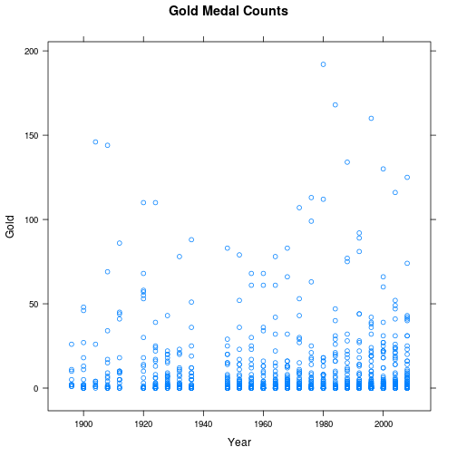

```r
xyplot(Gold~Year, data = medal_counts_wide, main = "Gold Medal Counts")
```

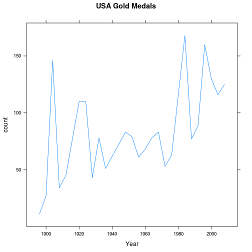

```r
xyplot(count~Year, data = usa_gold_medals, type = "l", main = "USA Gold Medals")
```

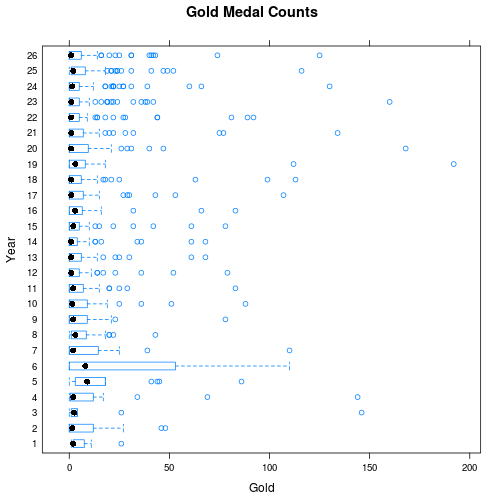

```r
# Boxplot
bwplot(Year~Gold, data = medal_counts_wide, main = "Gold Medal Counts")
```

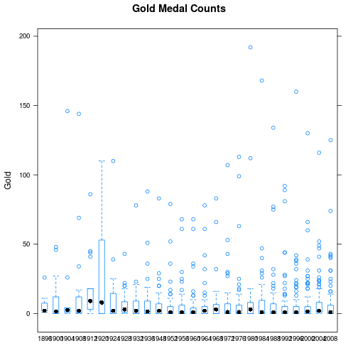

```r
# Flip the coordinates so year increases on the x-axis
# Explicitly turn Year into a factor
bwplot(Gold~factor(Year), data = medal_counts_wide, main = "Gold Medal Counts",
                  horizontal = FALSE)
```

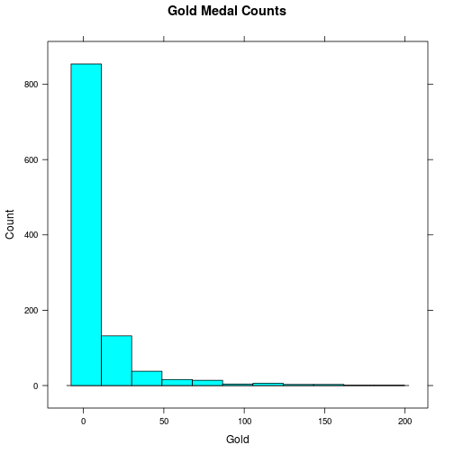

```r
# Histogram
histogram(~Gold, medal_counts_wide, type="count", main = "Gold Medal Counts")
```

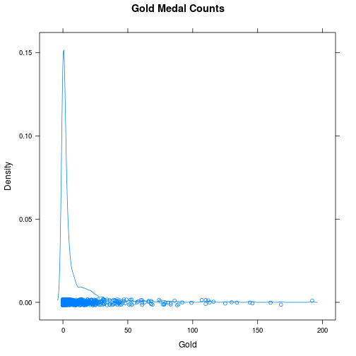

```r
# Density plot
densityplot(~Gold, medal_counts_wide, main = "Gold Medal Counts")
```

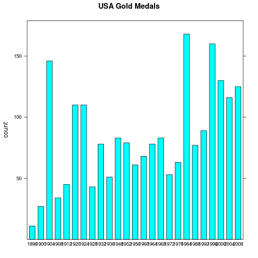

```r
# Bar chart
barchart(count~factor(Year), data = usa_gold_medals, width = 4,
                     main = "USA Gold Medals", horizontal = FALSE)
```

## Pros/cons of lattice

- lattice is useful for comparing cross-sectional variation in **trellis plots**
- Plots are generated in a single function call: you can't go back and add more once it's created
- Becoming a proficient user of lattice requires learning a huge array of graph-specific formulas and options

# Basic usage: ggplot2

The general call for ggplot2 graphics looks something like this:

```r
ggplot(data = , aes(x = ,y = , [options])) + geom_xxxx() + ... + ... + ...
```

Note that ggplot2 graphs in layers in a *continuing call* (hence the endless +...+...+...), which really makes the extra layer part of the call

```r
...+geom_xxxx(data = , aes(x = ,y = ,[options]),[options])+...+...+...
```

You can see the layering effect by comparing the same graph with different colors for each layer

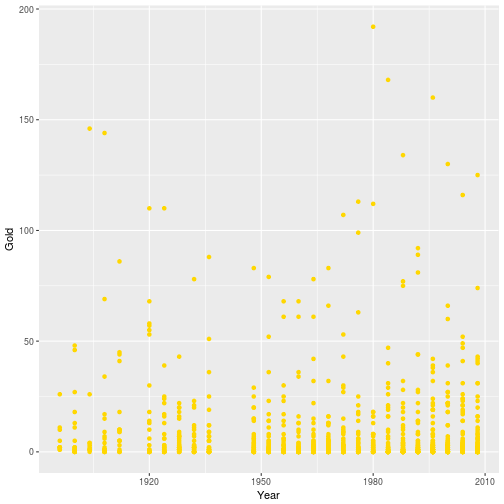

```r
p <- ggplot(data = medal_counts_wide, aes(x = Year, y = Gold)) +
                 geom_point(color = "gold")
p
```

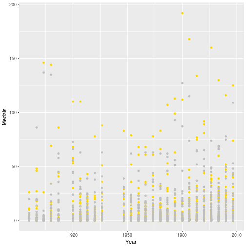

```r
p + geom_point(aes(x = Year, y = Silver), color = "gray") + ylab("Medals")
```

## Grammar of Graphics

ggplot2 syntax is very different from base graphics and lattice. It's built on the **grammar of graphics**. The basic idea is that the visualization of all data requires four items:

1. One or more **statistics** conveying information about the data (identities, means, medians, etc.)
2. A **coordinate system** that differentiates between the intersections of statistics (at most two for ggplot, three for lattice)
3. **Geometries** that differentiate between off-coordinate variation in *kind*
4. **Scales** that differentiate between off-coordinate variation in *degree*

ggplot2 allows the user to manipulate all four of these items.

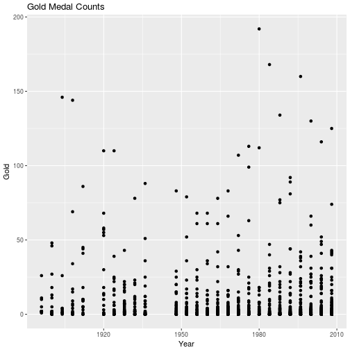

```r
ggplot(medal_counts_wide, aes(x = Year, y = Gold)) + geom_point() +
                          ggtitle("Gold Medal Counts")
```

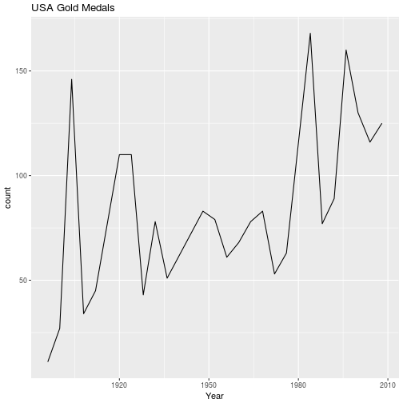

```r
ggplot(usa_gold_medals, aes(x = Year, y = count)) + geom_line() +
                        ggtitle("USA Gold Medals")
```

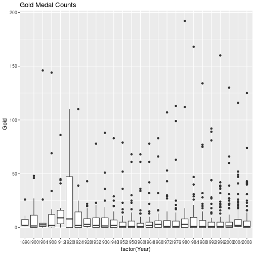

```r
# Boxplots
ggplot(medal_counts_wide, aes(x = factor(Year), y = Gold)) +
                          geom_boxplot() + ggtitle("Gold Medal Counts")
```

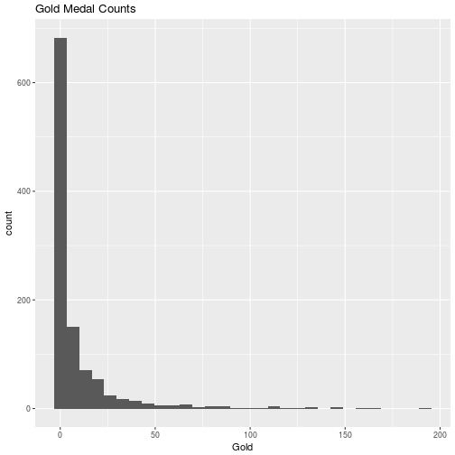

```r
# Histogram
ggplot(medal_counts_wide, aes(x = Gold)) + geom_histogram() +
                          ggtitle("Gold Medal Counts")
```

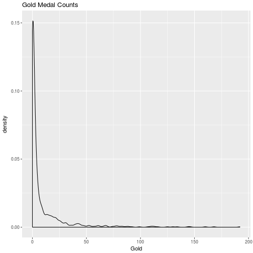

```r
# Density plot
ggplot(medal_counts_wide, aes(x = Gold)) + geom_density() +
                          ggtitle("Gold Medal Counts")
```

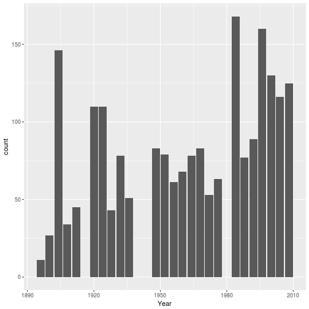

```r
# Bar chart
ggplot(usa_gold_medals, aes(x = Year, y = count)) + geom_bar(stat = "identity")
```

## ggplot2 and tidy data

- ggplot2 plays nice with dplyr and pipes. If you want to manipulate your data specifically for one plot but not save the new dataset, you can call your dplyr chain and pipe it directly into a ggplot call.

```r
# This combines the subsetting and plotting into one step
medal_counts %>%
  filter(Medal == "Gold") %>%
  filter(NOC == "USA") %>%
  ggplot(aes(x = Year, y = count)) + geom_line()
```

[output not shown]

- Base graphics/lattice and ggplot2 have one big difference: ggplot2 **requires** your data to be in tidy format. For base graphics, it can actually be helpful *not* to have your data in tidy format. The difference is that ggplot treats `Medal` as an aesthetic parameter that differentiates kinds of statistics, whereas base graphics treats each (year, medal) pair as a set of inputs to the plot. Compare:

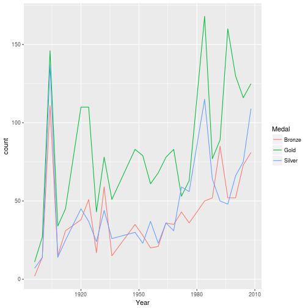

```r
usa_all_medals <- medal_counts %>% filter(NOC == "USA")

# ggplot2 call
ggplot(data = usa_all_medals, aes(x = Year, y = count)) +
            geom_line(aes(color = Medal))
```

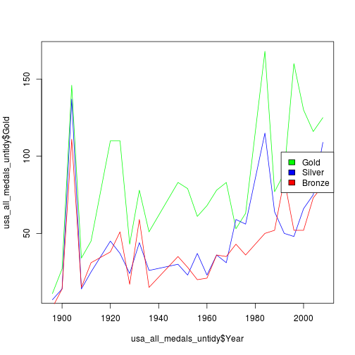

```r
usa_all_medals_untidy <- medal_counts_wide %>%
                      filter(NOC == "USA")

# Base graphics call
plot(usa_all_medals_untidy$Year, usa_all_medals_untidy$Gold, col = "green",
                                 type = "l")
lines(usa_all_medals_untidy$Year, usa_all_medals_untidy$Silver, col = "blue")
lines(usa_all_medals_untidy$Year, usa_all_medals_untidy$Bronze, col = "red")
legend("right", legend = c("Gold", "Silver", "Bronze"),
                fill = c("green", "blue", "red"))
```

## Pros/cons of ggplot2

- Allows you to add features in "layers"
- Automatically adjusts spacing and sizing as you add more layers
- Requires data to be in tidy format
- Syntax is different from base R -- there is a learning curve
- Plots are actually objects. You can assign them to a variable and do things with it (more on this later)

# Comparing lattice and ggplot2

- Density Plots
- Scatter Plots
- Line Plots
- Bar plots
- Box plots
- Trellis Plots
- Contour Plots
- Tile/Image Plots
- 3D Plots (lattice)

# lattice v. ggplot2: Densities

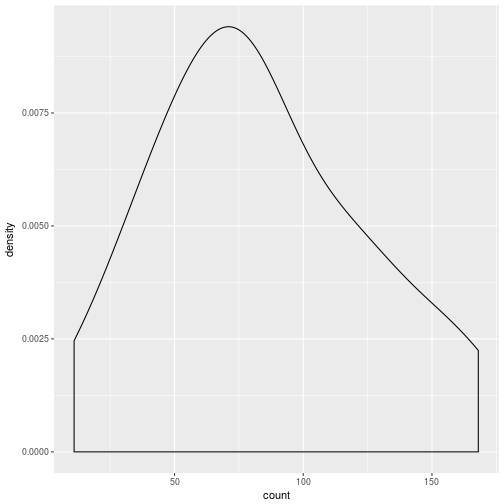

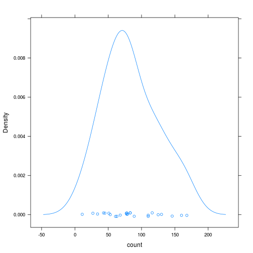

```r
ggplot(data = usa_gold_medals, aes(x = count)) + geom_density() # ggplot2
densityplot(~count, data = usa_gold_medals) # lattice
```

# lattice v. ggplot2: X-Y scatter plots

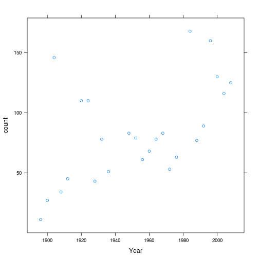

```r
ggplot(data = usa_gold_medals, aes(x = Year, y = count)) + geom_point() # ggplot2
xyplot(count~Year, data = usa_gold_medals) # lattice
```

[output not shown]

# lattice v. ggplot2: X-Y line plots

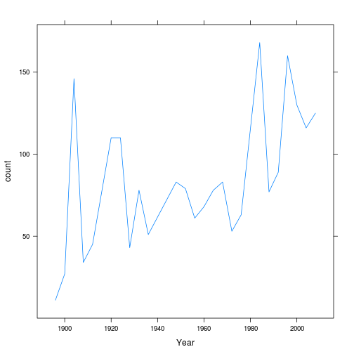

```r
ggplot(data = usa_gold_medals, aes(x = Year, y = count)) + geom_line() # ggplot2
xyplot(count~Year, data = usa_gold_medals, type = "l") # lattice
```

[output not shown]

# lattice v. ggplot2: bar plots

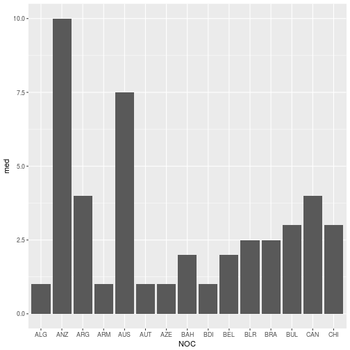

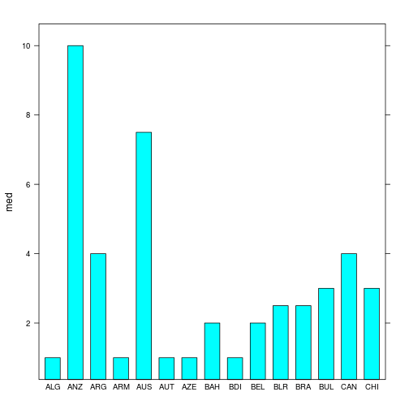

```r
# Create a dataframe of median number of gold medals by country
# note that the conversion to 'double' is because the median
# calculation had an error with 'count' is stored as integer
median_gold_medals <- medal_counts %>%
  filter(Medal == "Gold") %>% mutate(count = as.double(count)) %>%
  group_by(NOC) %>%
  summarise(med = median(count))

ggplot(data = median_gold_medals[1:15, ], aes(x = NOC, y = med)) +
            geom_bar(stat="identity") # ggplot2
barchart(med~NOC, data = median_gold_medals[1:15, ]) # lattice
```

# lattice v. ggplot2: boxplots

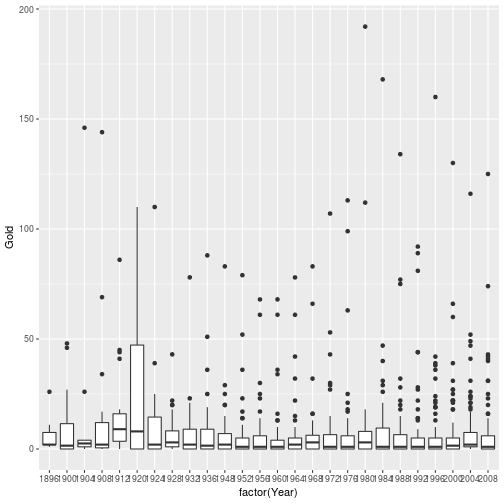

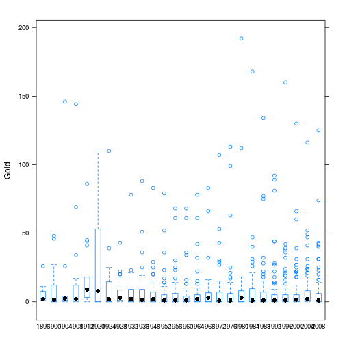

```r
# Notice that here, you must explicitly convert numeric years to factors
ggplot(data = medal_counts_wide, aes(x = factor(Year), y = Gold)) +
            geom_boxplot() # ggplot2
bwplot(Gold~factor(Year), data = medal_counts_wide, horizontal = FALSE) # lattice
```

# lattice v. ggplot2: "trellis" plots

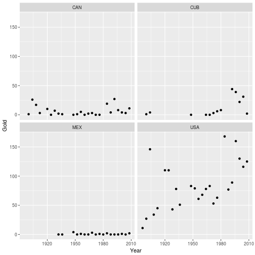

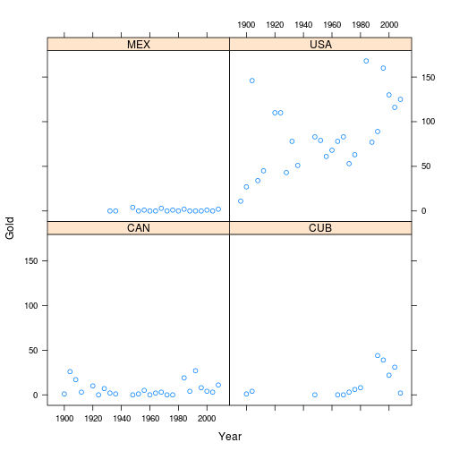

```r
# Subset the data to North America countries for easier viewing
northern_hem <- medal_counts_wide %>%
             filter(NOC %in% c("USA",
                            "CAN", # Canada
                            "CUB", # Cuba
                            "MEX")) # Mexico

ggplot(data = northern_hem, aes(x = Year, y = Gold)) + geom_point() +
            facet_wrap(~NOC) # ggplot2
xyplot(Gold~Year|NOC, data = northern_hem) # lattice
```

# lattice v. ggplot2: contour plots

```r
data(volcano) # Load volcano contour data
volcano[1:10, 1:10] # Examine volcano dataset (first 10 rows and columns)
```

```
##       [,1] [,2] [,3] [,4] [,5] [,6] [,7] [,8] [,9] [,10]
##  [1,]  100  100  101  101  101  101  101  100  100   100
##  [2,]  101  101  102  102  102  102  102  101  101   101
##  [3,]  102  102  103  103  103  103  103  102  102   102
##  [4,]  103  103  104  104  104  104  104  103  103   103
##  [5,]  104  104  105  105  105  105  105  104  104   103
##  [6,]  105  105  105  106  106  106  106  105  105   104
##  [7,]  105  106  106  107  107  107  107  106  106   105
##  [8,]  106  107  107  108  108  108  108  107  107   106
##  [9,]  107  108  108  109  109  109  109  108  108   107
## [10,]  108  109  109  110  110  110  110  109  109   108
```

```r
volcano3d <- melt(volcano) # Use reshape2 package to melt the data into tidy form
head(volcano3d) # Examine volcano3d dataset (head)
```

```
##   Var1 Var2 value
## 1    1    1   100
## 2    2    1   101
## 3    3    1   102
## 4    4    1   103
## 5    5    1   104
## 6    6    1   105
```

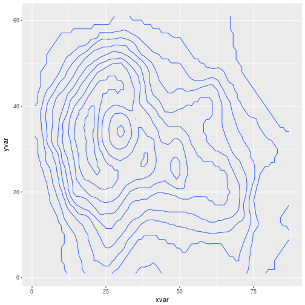

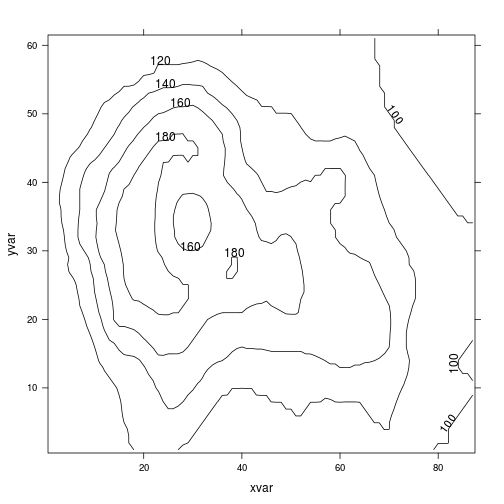

```r
names(volcano3d) <- c("xvar", "yvar", "zvar") # Rename volcano3d columns

ggplot(data = volcano3d, aes(x = xvar, y = yvar, z = zvar)) +
            geom_contour() # ggplot2
contourplot(zvar~xvar + yvar, data = volcano3d) # lattice
```

# lattice v. ggplot2: tile/image/level plots

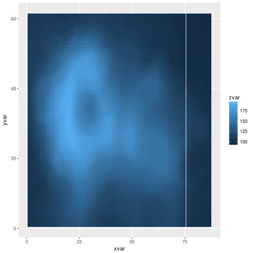

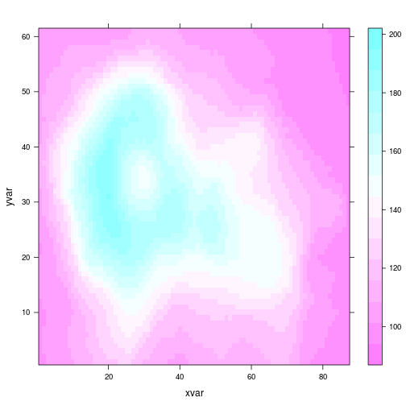

```r
ggplot(data = volcano3d, aes(x = xvar, y = yvar, z = zvar)) +
            geom_tile(aes(fill = zvar)) # ggplot2
levelplot(zvar~xvar + yvar, data = volcano3d) # lattice
```

# lattice: 3D plots

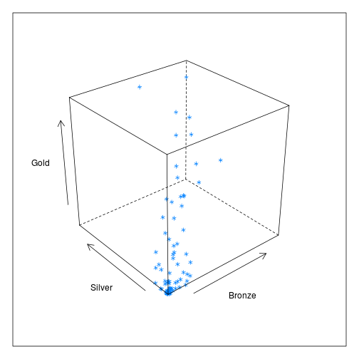

```r
# Create a subset of the dataset containing only data for France
cloud(Gold~Bronze*Silver, data = northern_hem)
```

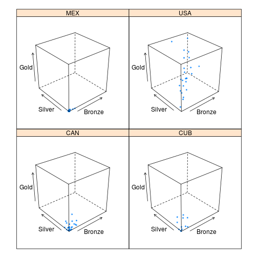

```r
cloud(Gold~Bronze*Silver|NOC, data = northern_hem)
```

# lattice v. ggplot2: options

Main difference to keep in mind: lattice options behave similarly to base plot, ggplot handles options in additional layers.

### Labels

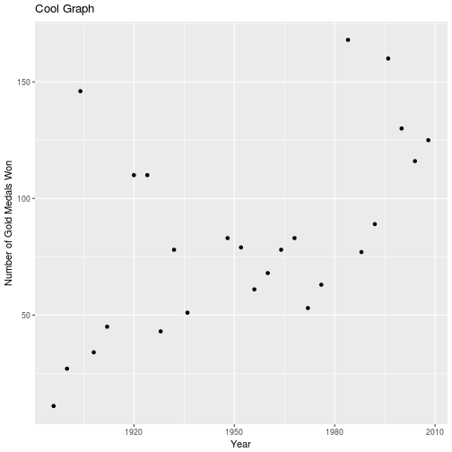

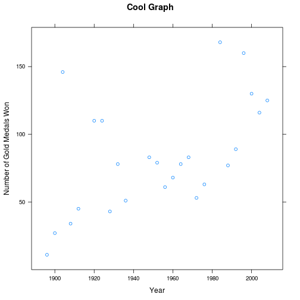

```r
ggplot(data = usa_gold_medals, aes(x = Year, y = count)) + geom_point() +
  xlab(label = "Year") +
  ylab(label = "Number of Gold Medals Won") +
  ggtitle(label = "Cool Graph") # ggplot2

xyplot(count~Year, data = usa_gold_medals,
       xlab = "Year", ylab = "Number of Gold Medals Won",
       main = "Cool Graph") # lattice
```

### Axis and point scales

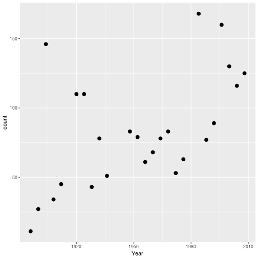

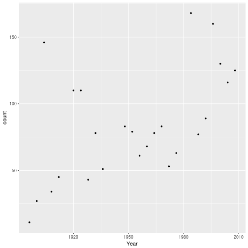

```r
ggplot(data = usa_gold_medals, aes(x = Year, y = count)) +
            geom_point() # ggplot2
ggplot(data = usa_gold_medals, aes(x = Year, y = count)) +
            geom_point(size=3) # ggplot2
ggplot(data = usa_gold_medals, aes(x = Year, y = count)) +
            geom_point(size=1) # ggplot2
```

[output not shown]

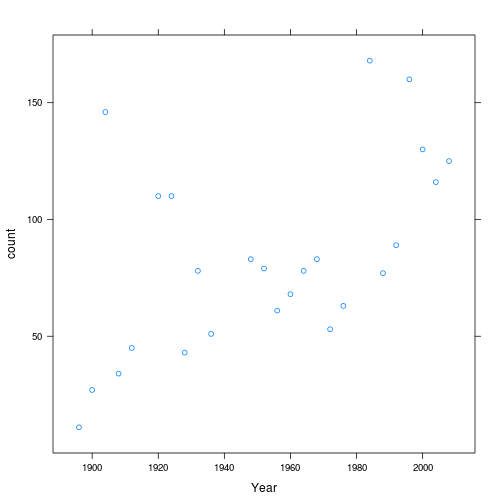

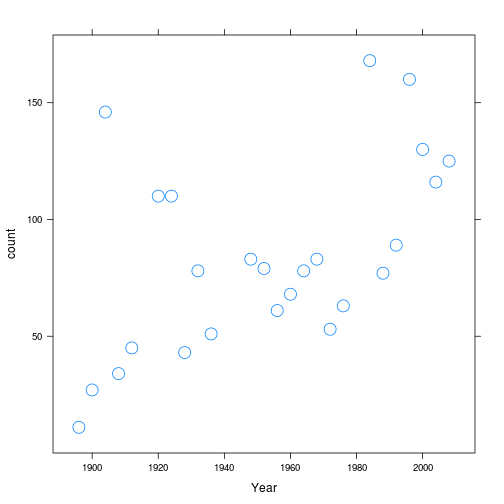

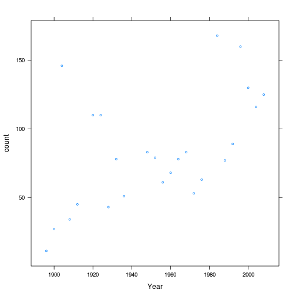

```r
xyplot(count~Year, data = usa_gold_medals) # lattice
xyplot(count~Year, data = usa_gold_medals, cex = 2) # lattice
xyplot(count~Year, data = usa_gold_medals, cex = .5) # lattice
```

### Graphical parameters

#### Colors

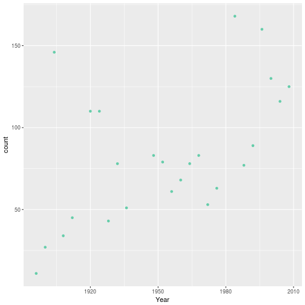

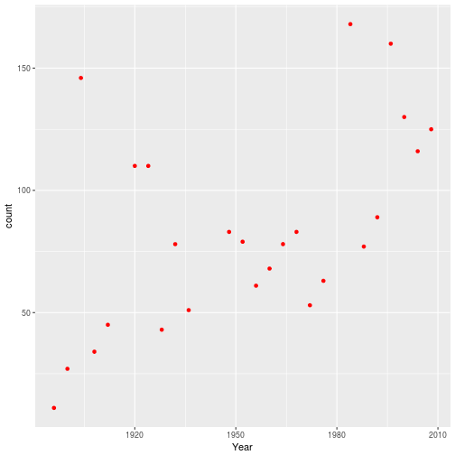

```r
ggplot(data = usa_gold_medals, aes(x = Year, y = count)) +
            geom_point(color = colors()[11]) # ggplot2
ggplot(data = usa_gold_medals, aes(x = Year, y = count)) +
            geom_point(color = "red") # ggplot2
```

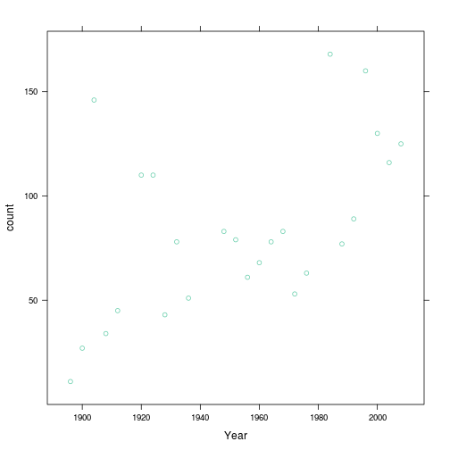

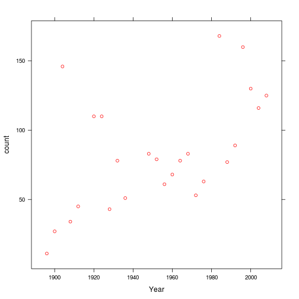

```r
xyplot(count~Year, data = usa_gold_medals, col = colors()[11]) #lattice
xyplot(count~Year, data = usa_gold_medals, col = "red") #lattice
```

#### Anatomy of aes()

```r
ggplot(data = , aes(x = , y = , color = , linetype = , shape = , size=))
```

These four aesthetic parameters (color, linetype, shape, size) can be used to show variation in *kind* (categories) and variation in *degree* (numeric).

Parameters passed into `aes` should be *variables* in your dataset.

Parameters passed to `geom_xxx` outside of `aes` should *not* be related to your dataset - they apply to the whole figure.

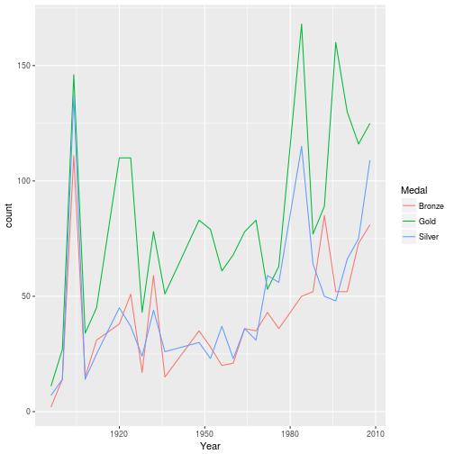

```r
ggplot(data = usa_all_medals, aes(x = Year, y = count)) +
            geom_line(aes(color = Medal))
```

Note what happens when we specify the color parameter outside of the aesthetic operator. ggplot2 views these specifications as invalid graphical parameters.

```r
ggplot(data = usa_all_medals, aes(x = Year, y = count)) +
            geom_point(color = Medal)
```

```
## Error in layer(data = data, mapping = mapping, stat = stat, geom = GeomPoint, : object 'Medal' not found
```

```r
ggplot(data = usa_all_medals, aes(x = Year, y = count)) +
            geom_point(color = "Medal")
```

```
## Error in grDevices::col2rgb(colour, TRUE): invalid color name 'Medal'
```

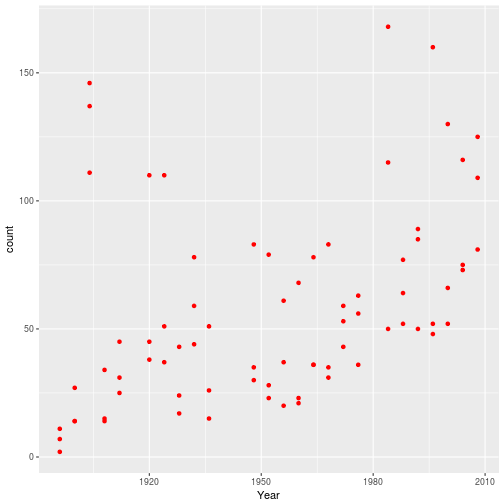

```r
ggplot(data = usa_all_medals, aes(x = Year, y = count)) +
            geom_point(color = "red")
```